# OpenStreetMap Project

Rupa Bisaria

September 7, 2017

# OpenStreetMap Data

OpenStreetMap is an editable map of the world, with contribution from volunteers from all over the world. This project creates and distributes free geographic data of the world.

Quoting from it’s [wiki](https://wiki.openstreetmap.org/wiki/Map_Features) page:

*OpenStreetMap represents physical features on the ground (e.g., roads or buildings) using tags attached to its basic data structures (its nodes, ways, and relations). Each tag describes a geographic attribute of the feature being shown by that specific node, way or relation.*

*OpenStreetMap’s free tagging system allows the map to include an unlimited number of attributes describing each feature. The community agrees on certain key and value combinations for the most commonly used tags, which act as informal standards. However, users can create new tags to improve the style of the map or to support analyses that rely on previously unmapped attributes of the features.*

# Project Objective

The project required to select an *‘area of the world in https://www.openstreetmap.org and use data munging techniques, such as assessing the quality of the data for validity, accuracy, completeness, consistency and uniformity, to clean the OpenStreetMap data’*. This clean data was to be saved to either MongoDB or SQL database, as per a pre-specified data schema. Finally, data was to be analysed as per the [Project Rubric](https://review.udacity.com/#!/projects/3168208620/rubric).

# Data Description

Data from Dubai-Abu Dhabi region from the following link: https://s3.amazonaws.com/metro-extracts.mapzen.com/dubai_abu-dhabi.osm.bz2 was used for the project.

Dubai and Abu Dhabi are part of a federation of emirates called United Arab Emirates (UAE). UAE is a federal absolute monarchy located at the southeast Arabian Peninsula in Western Asia. It is a federation of seven emirates, namely, Abu Dhabi, Ajman, Dubai, Fujairah, Ras Al Khaimah, Sharjah and Umm Al Quwain.

# Data Wrangling

Since a large part of the data is user generated, there is a huge likelihood of finding many discrepancies and errors in the data, which might need to be cleaned.

There are 862 unique keys of the ‘tag’ elements of elements ‘node’ and ‘way’. These are basically describing various [map features](https://wiki.openstreetmap.org/wiki/Map_Features) in an open street map.

Here are the top twenty keys sorted in descending order of their occurence in the data:

| Key | Count |
| --- | --- |
| highway | 183227 |
| source | 91029 |
| building | 88605 |
| name | 77374 |
| surface | 73926 |
| oneway | 69162 |
| addr:street | 52428 |
| lanes | 35757 |
| name:ar | 31158 |
| addr:housenumber | 29740 |
| amenity | 23222 |
| shop | 20169 |
| addr:city | 19997 |
| power | 17391 |
| addr:city:ar | 16049 |
| addr:street:ar | 15889 |
| landuse | 14473 |
| barrier | 13353 |
| maxspeed | 10581 |
| natural | 10299 |

Few of these tag keys were further investigated. The golden list of expected values were taken from [here](https://wiki.openstreetmap.org/wiki/Map_Features) and [here](https://taginfo.openstreetmap.org/keys)

## building

These were few values which didn’t match the expected values:

`['Office_And_entrance', 'office', 'Airport_terminal', 'Gate 3', 'Tourist_Exhibition', 'Offices', 'yes;mosque', 'MAJ Building', 'Complex_A_&_B']`

As per [wiki](https://wiki.openstreetmap.org/wiki/Map_Features#Building), building=commercial with office=* is to be used to describe the type of office. Also, building=yes is to be used where it is not possible to determine a more specific value.

For building value with ‘yes;mosque’, there are only 4 count of this value in the database as per [taginfo web site](https://taginfo.openstreetmap.org/keys/building), where most frequently used tag is ‘mosque’. While [wiki](https://wiki.openstreetmap.org/wiki/Semi-colon_value_separator) does allow such semi-colon separated values, it is also advised to use it only if necessary.

With these pointers, following mapping were done for the erroneous entries for building.

| Dirty | Clean |
| --- | --- |
| Airport_terminal | terminal |
| MAJ Building | yes |
| Tourist_Exhibition | yes |
| Gate 3 | yes |
| Offices | commercial |
| yes;mosque | mosque |

## surface

While most of the values were fine, there were few with spelling mistakes and some with extra backticks `.

`` ['unpaveds', 'running surface', 'asphalt`', 'Elevated', 'unpaved`', 'paving stones', 'paving_stoness', 'pavin', 'paving`'] ``

These were mapped against corrected values as follows:

| Dirty | Clean |
| --- | --- |
| running surface | running_surface |
| Elevated | elevated |
| paving_stoness | paving_stones |
| pavin | paving |
| paving stones | paving_stones |
| unpaveds | unpaved |
| `asphalt | asphalt |

## oneway

Audit of ‘oneway’ values resulted in following values:

`['Street 43', 'yes', '-1', 'tertiary', 'no']`

while the expected values as per [wiki](https://wiki.openstreetmap.org/wiki/Key:oneway) are:

`['yes','no','-1','reversible','alternating']`

Since there are only 6 entries whose values did not match the expected set of values, they were taken as ‘None’ for this project.

## addr:city

A list of most of the major cities in the region was created for mapping the cities in the data.

There were lot of problems in the data entries, starting from spelling errors, uppercase letters, non-city areas marked as city, arabic names and just a digit as an entry for a city. There were also few arabic entries too.

`Business Bay, Dubai`  
`abu dhabi`  
`1`  
`5`  
`Al Rahba` `DUBAI`

There were some values like `town` and `ME-12` or even `AE`. How mistakes can creep in into user-generatde data can be highlighted by the fact that there is an entry as `San Diego, CA` in Dubai-Abu Dhabi region! All such values were mapped to ‘None’. All the arabic names and numbers were also set to ‘None’

Although the map name suggests data from Abu Dhabi and Dubai, there were city data from other emirates too, which if fine.

Names with spelling errors or with all uppercase letters were mapped accordingly.

| Dirty | Clean |
| --- | --- |
| DUBAI | Dubai |
| abu dhabi | Abu Dhabi |

Entries were city names were accompanied with stree or other information were corrected as follows:

| Dirty | Clean |
| --- | --- |
| Dubai Media City, Dubai | Dubai |
| Jumeirah Beach, Dubai | Dubai |

## addr:street

Since many of the street names had spelling and typing errors, these values were mapped against correct values as follows:

Eg:

| Dirty | Clean |
| --- | --- |
| St | Street |
| st. | Street |
| sweet | Street |
| rd | Road |
| Roud | Road |
| Streetrr | Street |
| blvd | Boulevard |
| Atreet | Street |

Further, there were other issues which were sorted out one by one by using regex. Since the issues were so inter-twined, regex was required to be applied in a particular sequence to finally get the desired result.

Eg:

| Dirty | Clean |
| --- | --- |
| Street 6a | Street 6A |
| 11 B | Street 11B |
| 2-A | Street 2A |
| 12 D St | Street 12D |
| 6b St | Street 6B |
| Sa’ada Street (19th) | Sa’ada Street 19 |
| 55 | Street 55 |
| Jumeirah Village Triangle, District 2, Street 5 | Street 5 |
| Al Satwa StreetAl Bandoq Vegetable & Fruits | Al Satwa Street |
| 13C street , Al Quoz Industrial 3 | Street 13C |

There were entries like

`Al khail rd. business bay. Al khaleej al tejari 2 st. Al amal st. Churchill towers`

`Rose 2 - 17a St - Dubai 17a St Dubai United Arab Emirates`

which although look like correct entry but has so many extraneous information, it was very difficult to understand which is the correct name of the street.

There were lot of errors in data as not all the data entry were pertaining to the street name.

`khawaneej`

`Paragon Mall`

`No Fear Cafe`

`Arabian Ranches`

`Ibn Sina Medical Centre`

`24°26'24.5"N 54°27'03.8"E`

`P.O. Box 34429`

`Bahar 7 Jumeirah Beach Res, Marsa, Dubai, AE`

`Plot No. M-26, Area 54`

`Mezzanine Level, Spinneys Supermarket`

`residential`

`High Bay Business Center`

These values look very obviously to be wrong entries, hence such data entry were ignored and set as ‘None’.

There were values like

`(Inside of the Hotel The Cove Rotana Resort)`

`Camel race track near Sweihan`

where user has taken pains to put some description, but it may not be good enough. Here I chose to keep the later as `Camel Race Track Near Sweihan`

## arabic entries

Keys like ‘addr:street:ar’ and ‘name:ar’ with suffix ‘ar’ were all with values in arabic and have been ignored for this project.

# Data Exploration

## Data file size

Uncompressed data file: ‘dubai_abu-dhabi.osm’ is approximately 500MB in size.

## Number of nodes

There are in total 2431529 node elements.

```r
# SQL query:
cursor = conn.execute("SELECT COUNT(*) FROM nodes")
print "Node count  = ", cursor.fetchone()[0]
```

## Number of ways

There are in total 324346 ways elements.

Sql query for counting the number of ways:

```r
# SQL query:
cursor = conn.execute("SELECT COUNT(*) FROM ways")
print "Ways count  = ", cursor.fetchone()
```

## Unique users

There are 2450 unique user who contributed to the data.

Sql query for getting the number of unique user ids:

```r
# SQL query:
cursor = conn.execute("SELECT COUNT(DISTINCT(uid)) from nodes")
print "Unique uid count  = ", cursor.fetchone()[0]
```

## Top ten users

List of top ten users with most contibution:

| No. | user | uid | num |
| --- | --- | --- | --- |
| 0 | eXmajor | 561234 | 403358 |
| 1 | chachafish | 2237750 | 141500 |
| 2 | Seandebasti | 550560 | 137851 |
| 3 | Alex111X | 3451386 | 136847 |
| 4 | csdf | 28794 | 61949 |
| 5 | SEVEN | 127989 | 60409 |
| 6 | hellosun | 6127501 | 58903 |
| 7 | AndrewBuck | 214969 | 53321 |
| 8 | gellazp | 2199587 | 52969 |
| 9 | MozlTosh | 6127498 | 43238 |

```r
# SQL query:
df = pd.read_sql_query("SELECT user, COUNT(user) as num FROM nodes \
                    GROUP BY uid ORDER BY num DESC;", conn)
df[0:10]
```

User ‘eXmajor’ has made highest contribution to the data. His top ten contributions are:

| key | num |  |
| --- | --- | --- |
| 0 | highway | 17105 |
| 1 | building | 4550 |
| 2 | oneway | 3892 |
| 3 | barrier | 2468 |
| 4 | access | 2458 |
| 5 | amenity | 2322 |
| 6 | landuse | 2242 |
| 7 | leisure | 1206 |
| 8 | natural | 1059 |
| 9 | aeroway | 564 |

```r
# SQL query:
df = pd.read_sql_query("SELECT ways_tags.key, COUNT(ways_tags.key) as num FROM ways_tags \
                    JOIN ways ON ways_tags.id = ways.id \
                    WHERE ways.uid = '561234' \
                    GROUP BY ways_tags.key ORDER BY num DESC;", conn)
```

## Top ten keys

### For Nodes

```r
# SQL query:
df = pd.read_sql_query("SELECT key, COUNT(key) as num FROM nodes_tags \
                    GROUP BY key ORDER BY num DESC;", conn)
df[0:10]
```

[figure not shown]

### For Ways

```r
# SQL query:
df = pd.read_sql_query("SELECT key, COUNT(key) as num FROM ways_tags \
                    GROUP BY key ORDER BY num DESC;", conn)
df[0:10]
```

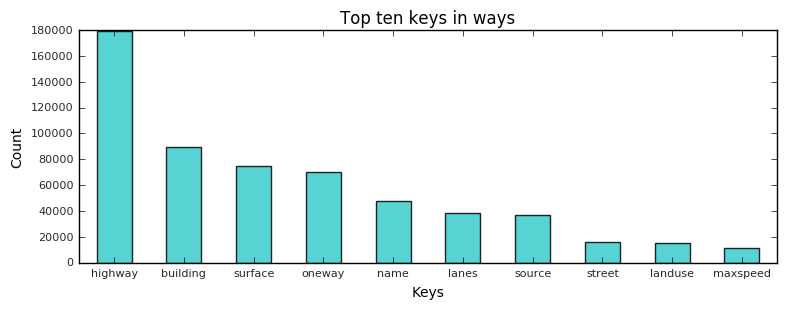

## Maximum nodes in a way element

One of the way element has 1960 node tags.

```r
# SQL query:
cursor = conn.execute("SELECT MAX(A.node_count) FROM \
           (SELECT COUNT(node_id) AS node_count FROM ways_nodes \
           GROUP BY id) A")
print "(Tag Id, Node Count)   = ", cursor.fetchone()[0]
```

Further investigating the dataset yielded more of such tags with more than 1000 nodes.

```r
# SQL query:
cursor = conn.execute("SELECT A.id, A.node_count FROM \
              (SELECT id, COUNT(node_id) AS node_count FROM ways_nodes \
              GROUP BY id) A WHERE A.node_count > 1000")
print "(Tag Id, Node Count) = ", cursor.fetchall()
```

`(Tag Id, Node Count) = [(170139278, 1086), (171171012, 1075), (194470882, 1094), (205958924, 1226), (216720271, 1628), (393225171, 1408), (393249907, 1434), (393254003, 1180), (393420807, 1266), (402883870, 1592), (402884861, 1450), (404074917, 1960), (404089376, 1469), (440574399, 1062), (440574403, 1133), (440574568, 1524), (440574586, 1264)]`

Checking for the details of the associated feature yielded a coastline, which explains the number of nodes.

```r
# SQL query:
cursor = conn.execute("SELECT key, value FROM ways_tags WHERE id = '402884861'")
print "Associated keys and values  = ", cursor.fetchall()
```

`Associated keys and values = [(u'natural', u'coastline')]`

# Improvement Suggestions

While wrangling the dataset, one things that came out very starkly was user’s confusion about the stated key and it’s required value. One could actually see sometimes users struggling to enter relevant data. Here are few suggestions that came in my mind in the process:

- Since many a values were required to be all in lowercase, text box for the same can be constrained accordingly. Also, although semi-solons are allowed, it has been advised to use it sparingly in the wiki. There could be a suggestion to the user for alternate stragegy if too many semi-colons are observed in the text box.
  - Benefit: This could ensure unniformity in the data entries, as per recommended guidelines.
  - Limitation: This solution, though, could be applicable only to few of the data entries.
- There were quite a few arabic entries in english language fields, which can also be constrained at the time of data entry.
  - Benefit: Entries in only expected language for a particular data field will be allowed, making the data entries cleaner
  - Limitations: There could be a situation were multiple language entries might be required for the same field. for example in case of arabic street names in this data set, there were entries with street name in arabic followed by street number as, say, ‘16A’.
- Since there are lot many spelling mistakes, and also, multiple versions of the same word like for eg: paved_stones and paved_stone, why not have a list of suggestions, a la Google, as a user is typing in, thereby, eleminating such scenario. There could be a spell check as well if that helps.
  - Benefit: Will ensure a cleaner data entry
  - Limitations: Might not work in case were an entirely new entry is made. Also, what if, previous entries had some spelling mistake, it might just get propogated further.
- There were few numeric entries for city names, and that seems little unlikely. An entry for such a field can be flagged as error to the user.
  - Benefit: Fields having alphanumric characters will be cleaner
  - Limitaions: It is only applicable to data fields which are very specifically alphanumeric, which could be problematic to presume given the scope of the map.
- There could be drop down menu of values if the list is reasonably small, for example, for oneway expected values are [‘yes’,‘no’,‘-1’,‘reversible’,‘alternating’] which can be easily picked from a drop down menu. This solution is of course constrained by the length of dropdown.
  - Benefit: Data entry for fields with fewer options can become cleaner.
  - Limitaions: Not applicable for data fields with larger options. Also, might pose a problem if the options increase over time, leading to technical issue of going back to drawing board for mitigating it.

Since, the open street map is used by people from world over, entering data in different languages, all these suggestions might not be applicable to all for various technical and other reasons. All said and done, getting a clean data at such a huge scale is an arduous task.

# Conclusion

As expected from any user generated data, there were quite a few errors and discrepancies in the data. While some had very few errors, other keys like street oy city names had lot of dirty entries. Also, while there were gold standards for some data entries which could be clean accordingly, there were no such standards easy available for, for example, city names. This project was a just a small attempt at cleaning a huge dataset like an open street map data, and wrangling such a data set for a clean version is indeed an enormous task.